# Tutorial16-multidimensionalArrays

```python
#importing the libraries
import numpy as np
import matplotlib.pyplot as plt
```

## 2 think+type: making 2D arrays

```python
def describe(a):

    '''
    --------input-------
    a = np.array

    -------output----------

    The describe function [prints descriptions of the array a

    '''


    print(f"length is {len(a)}")
    print(f"size is {a.size}")
    print(f"shape is {a.shape}")
    print(f"number of dimensions is {a.ndim}")
    print(f"contents are...\n{a}")
    print(f"maximum value is {a.max()}")
    print(f"minimum value is {a.min()}")
```

```python
oneDim = np.arange(0,24,4) #creating a 1 dimensional array to0 test the describe function
```

```python
describe(oneDim) #testing the describe function with a one-dimensional array
```

```
length is 6
size is 6
shape is (6,)
number of dimensions is 1
contents are...
[ 0  4  8 12 16 20]
maximum value is 20
minimum value is 0
```

```python
twoDim = oneDim.reshape(3,2) #this should create a two-dimensional array with 3 rows and 2 columns

describe(twoDim)
```

```
length is 3
size is 6
shape is (3, 2)
number of dimensions is 2
contents are...
[[ 0  4]
 [ 8 12]
 [16 20]]
maximum value is 20
minimum value is 0
```

```python
random = np.array([[1,2,4,8],[1,3,9,27]]) # creating another 2 dimensional numpy array to test
```

```python
describe(random)
```

```
length is 2
size is 8
shape is (2, 4)
number of dimensions is 2
contents are...
[[ 1  2  4  8]
 [ 1  3  9 27]]
maximum value is 27
minimum value is 1
```

```python
zeros = np.zeros([5,7]) #creating a 2-dimensional numpy array with 5 rows and 7 columns hopefully
print(zeros) #checking to make sure I did it correctly
```

```
[[0. 0. 0. 0. 0. 0. 0.]
 [0. 0. 0. 0. 0. 0. 0.]
 [0. 0. 0. 0. 0. 0. 0.]
 [0. 0. 0. 0. 0. 0. 0.]
 [0. 0. 0. 0. 0. 0. 0.]]
```

```python
describe(zeros)
```

```
length is 5
size is 35
shape is (5, 7)
number of dimensions is 2
contents are...
[[0. 0. 0. 0. 0. 0. 0.]
 [0. 0. 0. 0. 0. 0. 0.]
 [0. 0. 0. 0. 0. 0. 0.]
 [0. 0. 0. 0. 0. 0. 0.]
 [0. 0. 0. 0. 0. 0. 0.]]
maximum value is 0.0
minimum value is 0.0
```

```python
ones = np.ones([16,9])
```

```python
describe(ones)
```

```
length is 16
size is 144
shape is (16, 9)
number of dimensions is 2
contents are...
[[1. 1. 1. 1. 1. 1. 1. 1. 1.]
 [1. 1. 1. 1. 1. 1. 1. 1. 1.]
 [1. 1. 1. 1. 1. 1. 1. 1. 1.]
 [1. 1. 1. 1. 1. 1. 1. 1. 1.]
 [1. 1. 1. 1. 1. 1. 1. 1. 1.]
 [1. 1. 1. 1. 1. 1. 1. 1. 1.]
 [1. 1. 1. 1. 1. 1. 1. 1. 1.]
 [1. 1. 1. 1. 1. 1. 1. 1. 1.]
 [1. 1. 1. 1. 1. 1. 1. 1. 1.]
 [1. 1. 1. 1. 1. 1. 1. 1. 1.]
 [1. 1. 1. 1. 1. 1. 1. 1. 1.]
 [1. 1. 1. 1. 1. 1. 1. 1. 1.]
 [1. 1. 1. 1. 1. 1. 1. 1. 1.]
 [1. 1. 1. 1. 1. 1. 1. 1. 1.]
 [1. 1. 1. 1. 1. 1. 1. 1. 1.]
 [1. 1. 1. 1. 1. 1. 1. 1. 1.]]
maximum value is 1.0
minimum value is 1.0
```

answer for how are .size and .shape different from len()?

len() is just the number of elements in the first dimension of the numpy array

Size is the total number of elements in the numpy array. In a 1-dimensional numpy array, this will be equal to len(), but in higher N dimensions, this will be the product of the lengths of each dimension

shape () is a tuple with the number of dimensions listed in (1st dimension length, 2nd dimension length, 3rd dimension length, Nth dimension length)

## 3 think+code: make-your-own-array

```python
myarray = np.zeros([4,10]) #this should create a numpy array with four rows by ten columns of zeros
print(myarray)
```

```
[[0. 0. 0. 0. 0. 0. 0. 0. 0. 0.]
 [0. 0. 0. 0. 0. 0. 0. 0. 0. 0.]
 [0. 0. 0. 0. 0. 0. 0. 0. 0. 0.]
 [0. 0. 0. 0. 0. 0. 0. 0. 0. 0.]]
```

```python
# now to replace all the zeros with 42
myarray[myarray == 0] = 42 #repplacing all indexes where myarray == 0 is True with 42
print(myarray)

# I googled how to replace elements in an array as I forgot how to and the code above is what I found editted to work with my code
```

```
[[42. 42. 42. 42. 42. 42. 42. 42. 42. 42.]
 [42. 42. 42. 42. 42. 42. 42. 42. 42. 42.]
 [42. 42. 42. 42. 42. 42. 42. 42. 42. 42.]
 [42. 42. 42. 42. 42. 42. 42. 42. 42. 42.]]
```

```python
# yass that worked!!! Time to describe my 2 dimensional array
describe(myarray)
```

```
length is 4
size is 40
shape is (4, 10)
number of dimensions is 2
contents are...
[[42. 42. 42. 42. 42. 42. 42. 42. 42. 42.]
 [42. 42. 42. 42. 42. 42. 42. 42. 42. 42.]
 [42. 42. 42. 42. 42. 42. 42. 42. 42. 42.]
 [42. 42. 42. 42. 42. 42. 42. 42. 42. 42.]]
maximum value is 42.0
minimum value is 42.0
```

Since I am doing this after class at home, I was not able to compare with anyone else, and I cannot think of another way to do this without using a for loop

## 4 think+type: accessing and slicing 2D arrays

```python
print(twoDim) #printing my orginal two dimensaional array
```

```
[[ 0  4]
 [ 8 12]
 [16 20]]
```

```python
print(twoDim[1,1]) # this should print 12
```

```
12
```

```python
print(random)
```

```
[[ 1  2  4  8]
 [ 1  3  9 27]]
```

```python
print(random[1,3]) #this should print 27
```

```
27
```

```python
print(twoDim[:,0]) #this should print 0, 8, 16
```

```
[ 0  8 16]
```

```python
print(twoDim[1,:]) # this should print 8, 12
```

```
[ 8 12]
```

```python
print(random[0:2,3]) # this should print [8 27]
```

```
[ 8 27]
```

```python
print(random[0:2,1:4]) # this should print random without the first column of 1s
```

```
[[ 2  4  8]
 [ 3  9 27]]
```

## 5 think+code: modify-your-own-array

```python
print(myarray)
```

```
[[42. 42. 42. 42. 42. 42. 42. 42. 42. 42.]
 [42. 42. 42. 42. 42. 42. 42. 42. 42. 42.]
 [42. 42. 42. 42. 42. 42. 42. 42. 42. 42.]
 [42. 42. 42. 42. 42. 42. 42. 42. 42. 42.]]
```

```python
#putting this code from section 3 here so I can fix myarray after I inevitably break iot
myarray[myarray == 0] = 42 #repplacing all indexes where myarray == 0 is True with 42
print(myarray)
```

[output not shown]

```python
#haha I can use for loops for this as the tutorial doesn ot explicitly say not to use loops
```

```python
for i in range(len(myarray)): #running through the first dimension of my array
    if i == 1:
        for j in range(len(myarray[i])): #running through the second dimension of my array
            myarray[i][j] = -1 # replacing the value in myarray[row][coloumn] with -1

print(myarray)
```

```
[[42. 42. 42. 42. 42. 42. 42. 42. 42. 42.]
 [-1. -1. -1. -1. -1. -1. -1. -1. -1. -1.]
 [42. 42. 42. 42. 42. 42. 42. 42. 42. 42.]
 [42. 42. 42. 42. 42. 42. 42. 42. 42. 42.]]
```

```python
# well, I just saw the bottom part of this section that saw no for loops so I guess I will have to use something else
```

```python
print(f" orginal myaray:, \n {myarray}")
myarray[1] = -1 # replacing every element in the first row with -1

print(f"\n my new myarray:, \n {myarray}")
```

```
 orginal myaray:,
 [[42. 42. 42. 42. 42. 42. 42. 42. 42. 42.]
 [42. 42. 42. 42. 42. 42. 42. 42. 42. 42.]
 [42. 42. 42. 42. 42. 42. 42. 42. 42. 42.]
 [42. 42. 42. 42. 42. 42. 42. 42. 42. 42.]]

 my new myarray:,
 [[42. 42. 42. 42. 42. 42. 42. 42. 42. 42.]
 [-1. -1. -1. -1. -1. -1. -1. -1. -1. -1.]
 [42. 42. 42. 42. 42. 42. 42. 42. 42. 42.]
 [42. 42. 42. 42. 42. 42. 42. 42. 42. 42.]]
```

## 6 think+type: visualizing 2D arrays

#### Graphing 2 dimensional arrays

```
[[ 0  4]
 [ 8 12]
 [16 20]]
```

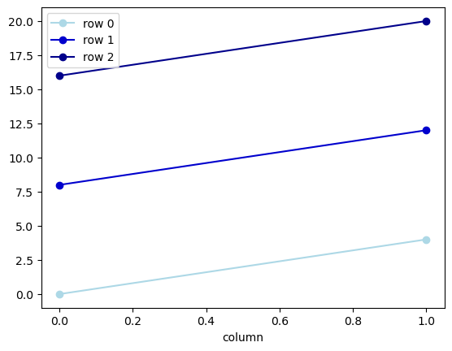

```python
print(twoDim)
import matplotlib.pyplot as plt

# Plotting the first row
plt.plot(twoDim[0, :], '-o', label='row 0', color="lightblue")

# plotting the second row
plt.plot(twoDim[1, :], '-o', label='row 1', color="mediumblue")

# plotting the third row
plt.plot(twoDim[2, :], '-o', label='row 2', color="darkblue")

# Setting the label for the x-axis
plt.xlabel('column')

# adding a legend describing each line
plt.legend();
```

While the plot above is intriguing, as it shows how I can begin to plot two-dimensional arrays, I would like to see how it looks when the arrays aren't all loinear with the same slope

```python
exponential = np.array([[1,2,4,8,16,32],[1,3,9,27,81,243],[1,4,16,64,256,1024]])
print(exponential)
```

```
[[   1    2    4    8   16   32]
 [   1    3    9   27   81  243]
 [   1    4   16   64  256 1024]]
```

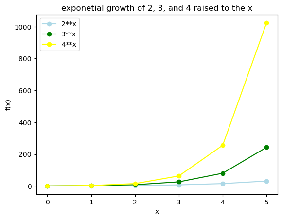

```python
plt.plot(exponential[0, :], '-o', label='2**x', color="lightblue")

# plotting the second row
plt.plot(exponential[1, :], '-o', label='3**x', color="green")

# plotting the third row
plt.plot(exponential[2, :], '-o', label='4**x', color="yellow")

# Setting the label for the x-axis
plt.xlabel('x')

#setting the label for the y axis
plt.ylabel('f(x)')

# adding a legend describing each line
plt.legend();

plt.title("exponetial growth of 2, 3, and 4 raised to the x")
```

ok, so that's what it would look like. That is kind of what I expected. Also, I know my graphs aren't smooth, but if I just added more points between x values, then they would become smoother and less linear

#### making a picture with a 2 dimensioanl array

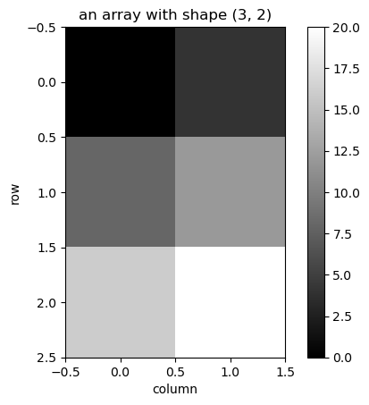

```python
# imshow shows a 2D image as an image
plt.imshow(twoDim, cmap='gray')
# set some labels
plt.title(f'an array with shape {twoDim.shape}')
plt.xlabel('column')
plt.ylabel('row')
# a colorbar shows us how color maps to number
plt.colorbar();
```

That's cool and all, but not really helpful for my twoDIm array. However, I could totally see the use for this for something such as analyzing telescope data from a gas cloud to see where the photon flux is the highest.

## 7 think+code: imshow-your-own-arra

```python
print(myarray)
```

```
[[42. 42. 42. 42. 42. 42. 42. 42. 42. 42.]
 [-1. -1. -1. -1. -1. -1. -1. -1. -1. -1.]
 [42. 42. 42. 42. 42. 42. 42. 42. 42. 42.]
 [42. 42. 42. 42. 42. 42. 42. 42. 42. 42.]]
```

since myarray is mostly the same except for the one row of -1, the image generated should just have one dark streak across the middle representing the row of -1, and the rest should be white, representing all of the 42s

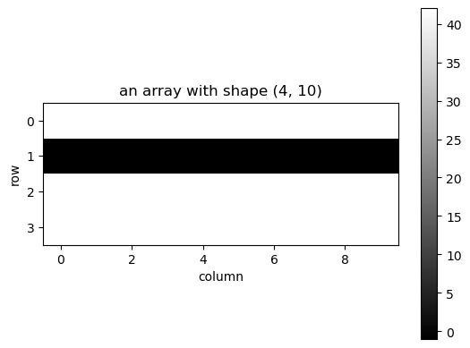

```python
# imshow shows a 2D image as an image
plt.imshow(myarray, cmap='gray')
# set some labels
plt.title(f'an array with shape {myarray.shape}')
plt.xlabel('column')
plt.ylabel('row')
# a colorbar shows us how color maps to number
plt.colorbar();
```

## 8 think+type: a bigger 2D array

```python
planet = np.load('planet.npy') #defining plaent as the numpy arrau from planets
```

```python
describe(planet) #describing the 2-dimensional numpy array, planet using the describe() function
```

```
length is 2233
size is 10300829
shape is (2233, 4613)
number of dimensions is 2
contents are...
[[0 0 0 ... 0 0 0]
 [0 0 0 ... 0 0 0]
 [0 0 0 ... 0 0 0]
 ...
 [0 0 0 ... 0 0 0]
 [0 0 0 ... 0 0 0]
 [0 0 0 ... 0 0 0]]
maximum value is 238
minimum value is 0
```

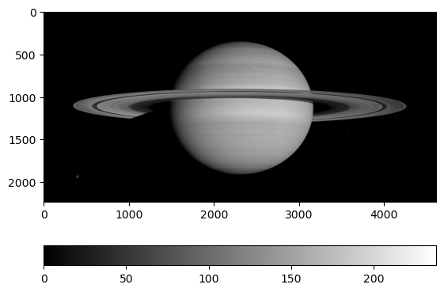

```python
# Visualizing planet using imshow

# display the 2D array as an image
plt.imshow(planet, cmap='gray')

# draw a colorbar along the bottom
plt.colorbar(orientation='horizontal');
```

OMG, the image of planet.npy is so beautiful! I love knowing how to visualize images using a multi-dimensional numpy array.

## 9 think+pair+code: colorful planet

#### I did this by myself at home

plt.imshow(planet, cmap='gray') After googling, matplotlib colormaps and then going to [matplotlib.org](https://matplotlib.org/stable/users/explain/colors/colormaps.html) I was able to learn that the way you change the color on an image is with the cmap = part of the plt.imshow() function. I will try changing the color map from cmap='gray' to cmap='plasma'

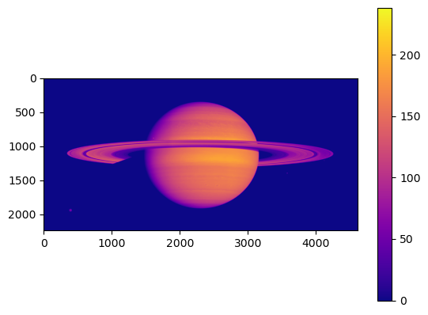

```python
plt.imshow(planet, cmap='plasma')

plt.colorbar(orientation='vertical'); #i'm also moving the colorbar to the side and vertical because I think that may look better
```

ok, first thought is that this does not look better. I mean, it helps me understand that I need to be black. Do to that, I will be switching to using the colormap, magma.

I also have changed my mind on the vertical color bar and will revert to horizontal

[figure not shown]

```python
plt.imshow(planet, cmap='magma')

plt.colorbar(orientation='horizontal');
```

The magma color map defintly looks better

[figure not shown]

```python
plt.imshow(planet, cmap='magma')

plt.axhline(y=1000, xmin=0, xmax=250, color='blue') # rawing a line through saturn and its; rings

plt.colorbar(orientation='horizontal');
```

when I plot the values in the array along the row where I drew the blue line through Saturn, I would expect that on the left and right edges near x=0 and x=4000, the plot will be near zero, as at those areas the image looks black, which is low on the colormap. Then, as it nears the center, it will steply climb and then plateau to a constant of between 100 and 200 as the majority of it is relatively uniform in color

```python
type(planet) #checking the type of planet so I know how to get the data to plot it
```

```
numpy.ndarray
```

```python
describe(planet) # learning a little more about the numpy array planet to help me plot it
```

```
length is 2233
size is 10300829
shape is (2233, 4613)
number of dimensions is 2
contents are...
[[0 0 0 ... 0 0 0]
 [0 0 0 ... 0 0 0]
 [0 0 0 ... 0 0 0]
 ...
 [0 0 0 ... 0 0 0]
 [0 0 0 ... 0 0 0]
 [0 0 0 ... 0 0 0]]
maximum value is 238
minimum value is 0
```

```python
List = planet[1000] # getting the list of elements from the row y =1000
```

```python
listArray = np.array(List) #converting that list into an array
```

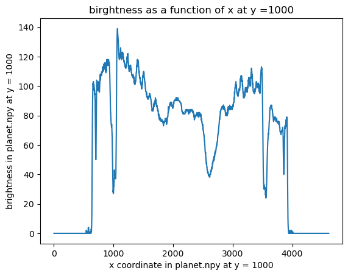

```python
plt.plot(listArray) # plottinh the array for y = 1000

plt.title("birghtness as a function of x at y =1000")

plt.xlabel("x coordinate in planet.npy at y = 1000")

plt.ylabel("brightness in planet.npy at y = 1000")
```

The plot is pretty similar to what I predicted, except for the two gaps at x = 1000 and x = 3500. This is between Saturn and the rings so the image would be more black here. The other major difference is that it does not reach as high as I predicted. I predicted it would plateau between y =100 and y = 200. The actual graph shows that the plateau is more like between y = 60 and y = 140